# Risk Factor Analysis

## Outcome Variable

**Outcome Variable:** sstunted

## Predictor Variables

**Intervention Variable:** impfloor

**Adjustment Set:**

unadjusted

## Stratifying Variables

The analysis was stratified on these variable(s):

- agecat
- studyid
- country

## Data Summary

| agecat | studyid | country | impfloor | sstunted | n_cell | n |
| --- | --- | --- | --- | --- | --- | --- |
| Birth | CMC-V-BCS-2002 | INDIA | 1 | 0 | 68 | 72 |
| Birth | CMC-V-BCS-2002 | INDIA | 1 | 1 | 4 | 72 |
| Birth | CMC-V-BCS-2002 | INDIA | 0 | 0 | 0 | 72 |
| Birth | CMC-V-BCS-2002 | INDIA | 0 | 1 | 0 | 72 |
| Birth | CONTENT | PERU | 1 | 0 | 2 | 2 |
| Birth | CONTENT | PERU | 1 | 1 | 0 | 2 |
| Birth | CONTENT | PERU | 0 | 0 | 0 | 2 |
| Birth | CONTENT | PERU | 0 | 1 | 0 | 2 |
| Birth | GMS-Nepal | NEPAL | 1 | 0 | 98 | 544 |
| Birth | GMS-Nepal | NEPAL | 1 | 1 | 2 | 544 |
| Birth | GMS-Nepal | NEPAL | 0 | 0 | 420 | 544 |
| Birth | GMS-Nepal | NEPAL | 0 | 1 | 24 | 544 |
| Birth | IRC | INDIA | 1 | 0 | 274 | 287 |
| Birth | IRC | INDIA | 1 | 1 | 13 | 287 |
| Birth | IRC | INDIA | 0 | 0 | 0 | 287 |
| Birth | IRC | INDIA | 0 | 1 | 0 | 287 |
| Birth | JiVitA-3 | BANGLADESH | 1 | 0 | 1307 | 22399 |
| Birth | JiVitA-3 | BANGLADESH | 1 | 1 | 87 | 22399 |
| Birth | JiVitA-3 | BANGLADESH | 0 | 0 | 18649 | 22399 |
| Birth | JiVitA-3 | BANGLADESH | 0 | 1 | 2356 | 22399 |
| Birth | JiVitA-4 | BANGLADESH | 1 | 0 | 289 | 2820 |
| Birth | JiVitA-4 | BANGLADESH | 1 | 1 | 18 | 2820 |
| Birth | JiVitA-4 | BANGLADESH | 0 | 0 | 2298 | 2820 |
| Birth | JiVitA-4 | BANGLADESH | 0 | 1 | 215 | 2820 |
| Birth | MAL-ED | BANGLADESH | 1 | 0 | 190 | 213 |
| Birth | MAL-ED | BANGLADESH | 1 | 1 | 6 | 213 |
| Birth | MAL-ED | BANGLADESH | 0 | 0 | 17 | 213 |
| Birth | MAL-ED | BANGLADESH | 0 | 1 | 0 | 213 |
| Birth | MAL-ED | BRAZIL | 1 | 0 | 55 | 60 |
| Birth | MAL-ED | BRAZIL | 1 | 1 | 3 | 60 |

[output cut: 162 more lines]

The following strata were considered:

- agecat: 24 months, studyid: CMC-V-BCS-2002, country: INDIA
- agecat: 24 months, studyid: CONTENT, country: PERU
- agecat: 24 months, studyid: GMS-Nepal, country: NEPAL
- agecat: 24 months, studyid: IRC, country: INDIA
- agecat: 24 months, studyid: JiVitA-3, country: BANGLADESH
- agecat: 24 months, studyid: JiVitA-4, country: BANGLADESH
- agecat: 24 months, studyid: MAL-ED, country: BANGLADESH
- agecat: 24 months, studyid: MAL-ED, country: BRAZIL
- agecat: 24 months, studyid: MAL-ED, country: INDIA
- agecat: 24 months, studyid: MAL-ED, country: NEPAL
- agecat: 24 months, studyid: MAL-ED, country: PERU
- agecat: 24 months, studyid: MAL-ED, country: SOUTH AFRICA
- agecat: 24 months, studyid: MAL-ED, country: TANZANIA, UNITED REPUBLIC OF
- agecat: 24 months, studyid: NIH-Birth, country: BANGLADESH
- agecat: 24 months, studyid: NIH-Crypto, country: BANGLADESH
- agecat: 24 months, studyid: PROVIDE, country: BANGLADESH
- agecat: 6 months, studyid: CMC-V-BCS-2002, country: INDIA
- agecat: 6 months, studyid: CONTENT, country: PERU
- agecat: 6 months, studyid: GMS-Nepal, country: NEPAL
- agecat: 6 months, studyid: IRC, country: INDIA
- agecat: 6 months, studyid: JiVitA-3, country: BANGLADESH
- agecat: 6 months, studyid: JiVitA-4, country: BANGLADESH
- agecat: 6 months, studyid: MAL-ED, country: BANGLADESH
- agecat: 6 months, studyid: MAL-ED, country: BRAZIL
- agecat: 6 months, studyid: MAL-ED, country: INDIA
- agecat: 6 months, studyid: MAL-ED, country: NEPAL
- agecat: 6 months, studyid: MAL-ED, country: PERU
- agecat: 6 months, studyid: MAL-ED, country: SOUTH AFRICA
- agecat: 6 months, studyid: MAL-ED, country: TANZANIA, UNITED REPUBLIC OF
- agecat: 6 months, studyid: NIH-Birth, country: BANGLADESH
- agecat: 6 months, studyid: NIH-Crypto, country: BANGLADESH
- agecat: 6 months, studyid: PROVIDE, country: BANGLADESH
- agecat: Birth, studyid: CMC-V-BCS-2002, country: INDIA
- agecat: Birth, studyid: CONTENT, country: PERU
- agecat: Birth, studyid: GMS-Nepal, country: NEPAL
- agecat: Birth, studyid: IRC, country: INDIA
- agecat: Birth, studyid: JiVitA-3, country: BANGLADESH
- agecat: Birth, studyid: JiVitA-4, country: BANGLADESH
- agecat: Birth, studyid: MAL-ED, country: BANGLADESH
- agecat: Birth, studyid: MAL-ED, country: BRAZIL
- agecat: Birth, studyid: MAL-ED, country: INDIA
- agecat: Birth, studyid: MAL-ED, country: NEPAL
- agecat: Birth, studyid: MAL-ED, country: PERU
- agecat: Birth, studyid: MAL-ED, country: SOUTH AFRICA
- agecat: Birth, studyid: MAL-ED, country: TANZANIA, UNITED REPUBLIC OF
- agecat: Birth, studyid: NIH-Birth, country: BANGLADESH
- agecat: Birth, studyid: NIH-Crypto, country: BANGLADESH
- agecat: Birth, studyid: PROVIDE, country: BANGLADESH

### Dropped Strata

Some strata were dropped due to rare outcomes:

- agecat: Birth, studyid: CMC-V-BCS-2002, country: INDIA
- agecat: Birth, studyid: CONTENT, country: PERU
- agecat: Birth, studyid: GMS-Nepal, country: NEPAL
- agecat: Birth, studyid: IRC, country: INDIA
- agecat: Birth, studyid: MAL-ED, country: BANGLADESH
- agecat: Birth, studyid: MAL-ED, country: BRAZIL
- agecat: Birth, studyid: MAL-ED, country: INDIA
- agecat: Birth, studyid: MAL-ED, country: NEPAL
- agecat: Birth, studyid: MAL-ED, country: PERU
- agecat: Birth, studyid: MAL-ED, country: SOUTH AFRICA
- agecat: Birth, studyid: MAL-ED, country: TANZANIA, UNITED REPUBLIC OF
- agecat: Birth, studyid: NIH-Birth, country: BANGLADESH
- agecat: Birth, studyid: NIH-Crypto, country: BANGLADESH
- agecat: Birth, studyid: PROVIDE, country: BANGLADESH
- agecat: 6 months, studyid: CMC-V-BCS-2002, country: INDIA
- agecat: 6 months, studyid: CONTENT, country: PERU
- agecat: 6 months, studyid: GMS-Nepal, country: NEPAL
- agecat: 6 months, studyid: IRC, country: INDIA
- agecat: 6 months, studyid: MAL-ED, country: BANGLADESH
- agecat: 6 months, studyid: MAL-ED, country: BRAZIL
- agecat: 6 months, studyid: MAL-ED, country: INDIA
- agecat: 6 months, studyid: MAL-ED, country: NEPAL
- agecat: 6 months, studyid: MAL-ED, country: PERU
- agecat: 6 months, studyid: MAL-ED, country: SOUTH AFRICA
- agecat: 6 months, studyid: MAL-ED, country: TANZANIA, UNITED REPUBLIC OF
- agecat: 6 months, studyid: NIH-Birth, country: BANGLADESH
- agecat: 24 months, studyid: CMC-V-BCS-2002, country: INDIA
- agecat: 24 months, studyid: CONTENT, country: PERU
- agecat: 24 months, studyid: GMS-Nepal, country: NEPAL
- agecat: 24 months, studyid: IRC, country: INDIA
- agecat: 24 months, studyid: MAL-ED, country: BANGLADESH
- agecat: 24 months, studyid: MAL-ED, country: BRAZIL
- agecat: 24 months, studyid: MAL-ED, country: INDIA
- agecat: 24 months, studyid: MAL-ED, country: NEPAL
- agecat: 24 months, studyid: MAL-ED, country: PERU
- agecat: 24 months, studyid: MAL-ED, country: SOUTH AFRICA
- agecat: 24 months, studyid: MAL-ED, country: TANZANIA, UNITED REPUBLIC OF

## Methods Detail

We’re interested in the causal parameters $E[Y_a]$ for all values of $a \in \mathcal{A}$. These parameters represent the mean outcome if, possibly contrary to fact, we intervened to set all units to have $A=a$. Under the randomization and positivity assumptions, these are identified by the statistical parameters $\psi_a=E_W[E_{Y|A,W}(Y|A=a,W)]$. In addition, we’re interested in the mean of $Y$, $E[Y]$ under no intervention (the observed mean). We will estimate these parameters by using SuperLearner to fit the relevant likelihood factors – $E_{Y|A,W}(Y|A=a,W)$ and $p(A=a|W)$, and then updating our likelihood fit using a joint TMLE.

For unadjusted analyses ($W=\{\}$), initial likelihoods were estimated using Lrnr_glm to estimate the simple $E(Y|A)$ and Lrnr_mean to estimate $p(A)$. For adjusted analyses, a small library containing Lrnr_glmnet, Lrnr_xgboost, and Lrnr_mean was used.

Having estimated these parameters, we will then use the delta method to estimate relative risks and attributable risks relative to a prespecified baseline level of $A$.

# Results Detail

## Results Plots

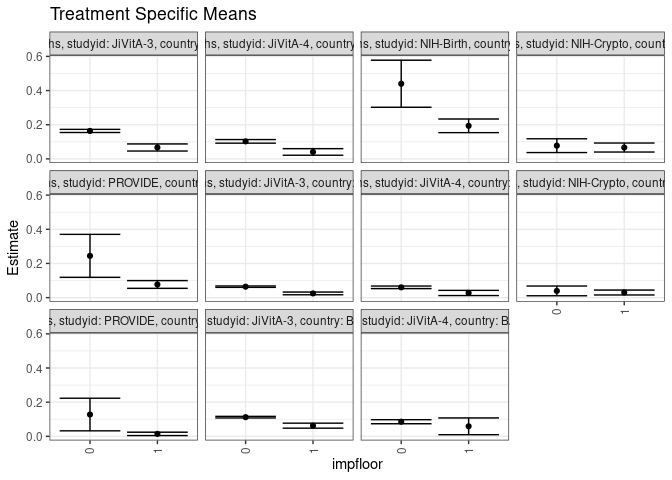

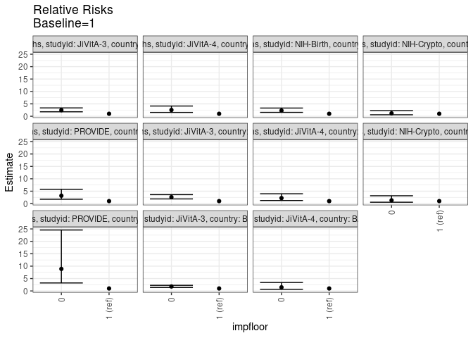

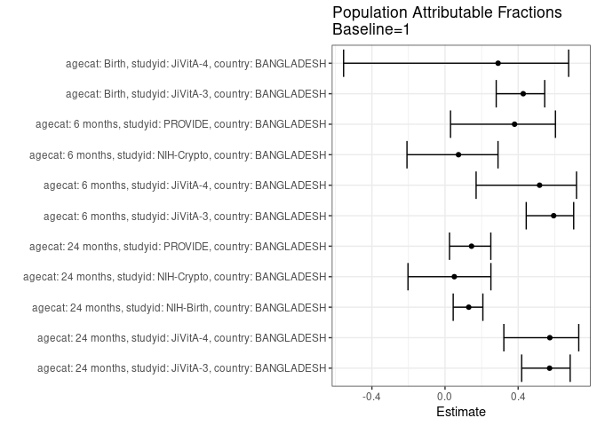

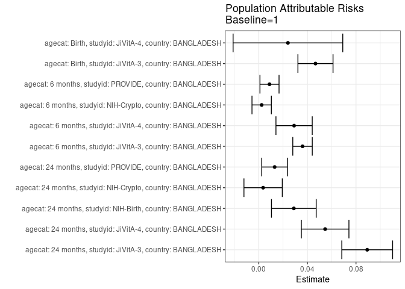

## Results Table

### Parameter: TSM

| agecat | studyid | country | intervention_level | baseline_level | estimate | ci_lower | ci_upper |
| --- | --- | --- | --- | --- | --- | --- | --- |
| Birth | JiVitA-3 | BANGLADESH | 1 | NA | 0.0624103 | 0.0478121 | 0.0770086 |
| Birth | JiVitA-3 | BANGLADESH | 0 | NA | 0.1121638 | 0.1074147 | 0.1169129 |
| Birth | JiVitA-4 | BANGLADESH | 1 | NA | 0.0586319 | 0.0096070 | 0.1076568 |
| Birth | JiVitA-4 | BANGLADESH | 0 | NA | 0.0855551 | 0.0737653 | 0.0973449 |
| 6 months | JiVitA-3 | BANGLADESH | 1 | NA | 0.0245734 | 0.0166417 | 0.0325050 |
| 6 months | JiVitA-3 | BANGLADESH | 0 | NA | 0.0640188 | 0.0599190 | 0.0681186 |
| 6 months | JiVitA-4 | BANGLADESH | 1 | NA | 0.0271186 | 0.0118993 | 0.0423380 |
| 6 months | JiVitA-4 | BANGLADESH | 0 | NA | 0.0602267 | 0.0527918 | 0.0676617 |
| 6 months | NIH-Crypto | BANGLADESH | 1 | NA | 0.0297952 | 0.0154049 | 0.0441854 |
| 6 months | NIH-Crypto | BANGLADESH | 0 | NA | 0.0393258 | 0.0107520 | 0.0678997 |
| 6 months | PROVIDE | BANGLADESH | 1 | NA | 0.0143627 | 0.0044736 | 0.0242517 |
| 6 months | PROVIDE | BANGLADESH | 0 | NA | 0.1276596 | 0.0321760 | 0.2231431 |
| 24 months | JiVitA-3 | BANGLADESH | 1 | NA | 0.0667656 | 0.0459874 | 0.0875438 |
| 24 months | JiVitA-3 | BANGLADESH | 0 | NA | 0.1635791 | 0.1544106 | 0.1727476 |
| 24 months | JiVitA-4 | BANGLADESH | 1 | NA | 0.0406360 | 0.0213475 | 0.0599246 |
| 24 months | JiVitA-4 | BANGLADESH | 0 | NA | 0.1026316 | 0.0921035 | 0.1131597 |
| 24 months | NIH-Birth | BANGLADESH | 1 | NA | 0.1936340 | 0.1536999 | 0.2335680 |
| 24 months | NIH-Birth | BANGLADESH | 0 | NA | 0.4400000 | 0.3022497 | 0.5777503 |
| 24 months | NIH-Crypto | BANGLADESH | 1 | NA | 0.0664740 | 0.0402002 | 0.0927477 |
| 24 months | NIH-Crypto | BANGLADESH | 0 | NA | 0.0773810 | 0.0369378 | 0.1178241 |
| 24 months | PROVIDE | BANGLADESH | 1 | NA | 0.0769231 | 0.0542814 | 0.0995647 |
| 24 months | PROVIDE | BANGLADESH | 0 | NA | 0.2444444 | 0.1187717 | 0.3701172 |

### Parameter: E(Y)

| agecat | studyid | country | intervention_level | baseline_level | estimate | ci_lower | ci_upper |
| --- | --- | --- | --- | --- | --- | --- | --- |
| Birth | JiVitA-3 | BANGLADESH | NA | NA | 0.1090674 | 0.1045072 | 0.1136275 |
| Birth | JiVitA-4 | BANGLADESH | NA | NA | 0.0826241 | 0.0709364 | 0.0943118 |
| 6 months | JiVitA-3 | BANGLADESH | NA | NA | 0.0605735 | 0.0567154 | 0.0644317 |
| 6 months | JiVitA-4 | BANGLADESH | NA | NA | 0.0561774 | 0.0493938 | 0.0629611 |
| 6 months | NIH-Crypto | BANGLADESH | NA | NA | 0.0321678 | 0.0192256 | 0.0451101 |
| 6 months | PROVIDE | BANGLADESH | NA | NA | 0.0231788 | 0.0111688 | 0.0351888 |
| 24 months | JiVitA-3 | BANGLADESH | NA | NA | 0.1559995 | 0.1472541 | 0.1647450 |
| 24 months | JiVitA-4 | BANGLADESH | NA | NA | 0.0952381 | 0.0856745 | 0.1048017 |
| 24 months | NIH-Birth | BANGLADESH | NA | NA | 0.2224824 | 0.1829871 | 0.2619778 |
| 24 months | NIH-Crypto | BANGLADESH | NA | NA | 0.0700389 | 0.0479542 | 0.0921236 |
| 24 months | PROVIDE | BANGLADESH | NA | NA | 0.0899654 | 0.0666186 | 0.1133122 |

### Parameter: RR

| agecat | studyid | country | intervention_level | baseline_level | estimate | ci_lower | ci_upper |
| --- | --- | --- | --- | --- | --- | --- | --- |
| Birth | JiVitA-3 | BANGLADESH | 1 | 1 | 1.000000 | 1.0000000 | 1.000000 |
| Birth | JiVitA-3 | BANGLADESH | 0 | 1 | 1.797199 | 1.4161898 | 2.280714 |
| Birth | JiVitA-4 | BANGLADESH | 1 | 1 | 1.000000 | 1.0000000 | 1.000000 |
| Birth | JiVitA-4 | BANGLADESH | 0 | 1 | 1.459190 | 0.6242962 | 3.410617 |
| 6 months | JiVitA-3 | BANGLADESH | 1 | 1 | 1.000000 | 1.0000000 | 1.000000 |
| 6 months | JiVitA-3 | BANGLADESH | 0 | 1 | 2.605210 | 1.8793792 | 3.611362 |
| 6 months | JiVitA-4 | BANGLADESH | 1 | 1 | 1.000000 | 1.0000000 | 1.000000 |
| 6 months | JiVitA-4 | BANGLADESH | 0 | 1 | 2.220861 | 1.2481235 | 3.951711 |
| 6 months | NIH-Crypto | BANGLADESH | 1 | 1 | 1.000000 | 1.0000000 | 1.000000 |
| 6 months | NIH-Crypto | BANGLADESH | 0 | 1 | 1.319874 | 0.5515999 | 3.158206 |
| 6 months | PROVIDE | BANGLADESH | 1 | 1 | 1.000000 | 1.0000000 | 1.000000 |
| 6 months | PROVIDE | BANGLADESH | 0 | 1 | 8.888298 | 3.2159417 | 24.565693 |
| 24 months | JiVitA-3 | BANGLADESH | 1 | 1 | 1.000000 | 1.0000000 | 1.000000 |
| 24 months | JiVitA-3 | BANGLADESH | 0 | 1 | 2.450051 | 1.7878168 | 3.357587 |
| 24 months | JiVitA-4 | BANGLADESH | 1 | 1 | 1.000000 | 1.0000000 | 1.000000 |
| 24 months | JiVitA-4 | BANGLADESH | 0 | 1 | 2.525629 | 1.5497908 | 4.115913 |
| 24 months | NIH-Birth | BANGLADESH | 1 | 1 | 1.000000 | 1.0000000 | 1.000000 |
| 24 months | NIH-Birth | BANGLADESH | 0 | 1 | 2.272329 | 1.5619140 | 3.305866 |
| 24 months | NIH-Crypto | BANGLADESH | 1 | 1 | 1.000000 | 1.0000000 | 1.000000 |
| 24 months | NIH-Crypto | BANGLADESH | 0 | 1 | 1.164079 | 0.6045058 | 2.241631 |
| 24 months | PROVIDE | BANGLADESH | 1 | 1 | 1.000000 | 1.0000000 | 1.000000 |
| 24 months | PROVIDE | BANGLADESH | 0 | 1 | 3.177778 | 1.7572854 | 5.746518 |

### Parameter: PAR

| agecat | studyid | country | intervention_level | baseline_level | estimate | ci_lower | ci_upper |
| --- | --- | --- | --- | --- | --- | --- | --- |
| Birth | JiVitA-3 | BANGLADESH | 1 | NA | 0.0466570 | 0.0322120 | 0.0611020 |
| Birth | JiVitA-4 | BANGLADESH | 1 | NA | 0.0239922 | -0.0211387 | 0.0691231 |
| 6 months | JiVitA-3 | BANGLADESH | 1 | NA | 0.0360002 | 0.0279832 | 0.0440171 |
| 6 months | JiVitA-4 | BANGLADESH | 1 | NA | 0.0290588 | 0.0141291 | 0.0439885 |
| 6 months | NIH-Crypto | BANGLADESH | 1 | NA | 0.0023727 | -0.0055977 | 0.0103431 |
| 6 months | PROVIDE | BANGLADESH | 1 | NA | 0.0088162 | 0.0009634 | 0.0166689 |
| 24 months | JiVitA-3 | BANGLADESH | 1 | NA | 0.0892340 | 0.0683217 | 0.1101462 |
| 24 months | JiVitA-4 | BANGLADESH | 1 | NA | 0.0546021 | 0.0350170 | 0.0741871 |
| 24 months | NIH-Birth | BANGLADESH | 1 | NA | 0.0288485 | 0.0104466 | 0.0472504 |
| 24 months | NIH-Crypto | BANGLADESH | 1 | NA | 0.0035649 | -0.0122046 | 0.0193344 |
| 24 months | PROVIDE | BANGLADESH | 1 | NA | 0.0130423 | 0.0024474 | 0.0236372 |

### Parameter: PAF

| agecat | studyid | country | intervention_level | baseline_level | estimate | ci_lower | ci_upper |
| --- | --- | --- | --- | --- | --- | --- | --- |
| Birth | JiVitA-3 | BANGLADESH | 1 | NA | 0.4277818 | 0.2800381 | 0.5452070 |
| Birth | JiVitA-4 | BANGLADESH | 1 | NA | 0.2903776 | -0.5548346 | 0.6761302 |
| 6 months | JiVitA-3 | BANGLADESH | 1 | NA | 0.5943216 | 0.4441778 | 0.7039071 |
| 6 months | JiVitA-4 | BANGLADESH | 1 | NA | 0.5172681 | 0.1700930 | 0.7192094 |
| 6 months | NIH-Crypto | BANGLADESH | 1 | NA | 0.0737592 | -0.2081364 | 0.2898798 |
| 6 months | PROVIDE | BANGLADESH | 1 | NA | 0.3803539 | 0.0300934 | 0.6041256 |
| 24 months | JiVitA-3 | BANGLADESH | 1 | NA | 0.5720142 | 0.4192279 | 0.6846064 |
| 24 months | JiVitA-4 | BANGLADESH | 1 | NA | 0.5733216 | 0.3218093 | 0.7315585 |
| 24 months | NIH-Birth | BANGLADESH | 1 | NA | 0.1296663 | 0.0446808 | 0.2070915 |
| 24 months | NIH-Crypto | BANGLADESH | 1 | NA | 0.0508992 | -0.2025819 | 0.2509513 |
| 24 months | PROVIDE | BANGLADESH | 1 | NA | 0.1449704 | 0.0245485 | 0.2505259 |